# Unsupervised Clustering of Breast Cancer Samples

### Introduction

Modern molecular cancer research is virtually inseparable from bioinformatical analysis while omic approaches are becoming a common practice not only in academic but also diagnostic facilities [1][2]. Transcriptome and methylome analysis are some of the major tools used for elucidating molecular profiles of different cancer types that in turn could lead to advancements in cancer treatment [3]. In order to facilitate these processes, a few publicly available databases collect a constantly increasing number of cancer samples. The Cancer Genome Atlas (TCGA) is one of such platforms frequently used for validation or reconsideration of common cancer classification, detection of biomarkers, assessing prognostic values of certain molecular profiles, etc. [4].  
Breast cancer is a good manifestation of how contributions of big data analysis have led to refinements in molecular classification. This most common type of cancer in women can be defined by multiple criteria such as immunohistochemical, histopathological and molecular characteristics [5]. All distinct subtypes, however, still fall in to more general, hormone responsive and non-responsive groups that determines a subsequent treatment course and prognosis for a patient [5][6][7].  
Although aiding cancer research, such enormous data raise new challenges that bioinformaticians have to face. To process and integrate different omic platforms and render them biologically interpretable, Machine Learning (ML) tools are often applied to allow drawing sensible conclusions [8].  
Having those challenges in mind, I set out to find out whether unsupervised clustering of RNA-seq data could reveal distinct groups of breast cancer samples from TCGA database and if so, which differentially expressed genes contribute most to the formation of those clusters. Additionally, I addressed the methylation levels of the differentially expressed genes to test whether the epigenetic parameter could also reflect differences between samples.

### Methods and Results

#### Transcriptome Data Access

Using *TCGAbiolinks* package, RNAseq data of 500 samples were obtained from “TCGA-BRCA” project followed by the essential data normalization and transformation steps.

```r
#--------------------------------------------------------------------------------------
                                          #gene expression data
#--------------------------------------------------------------------------------------
samples500 <- matchedMetExp("TCGA-BRCA", n = 500)
#matchedMetExp will consider the same data for later during methylation data access

query <- GDCquery(project = "TCGA-BRCA",
                  data.category = "Gene expression",
                  data.type = "Gene expression quantification",
                  experimental.strategy = "RNA-Seq",
                  platform = "Illumina HiSeq",
                  file.type = "results",
                  legacy = TRUE,
                  barcode = samples500)
GDCdownload(query)
geneexpr <- GDCprepare(query)
ExpMatrix <- assay(geneexpr) #gene expression matrix

#NORMALIZATION AND FILTERING
dataPrep <- TCGAanalyze_Preprocessing(object=geneexpr,
                                          cor.cut = 0.6,
                                          datatype = "raw_count",
                                          filename = "AAIC.png")
#19947 genes 500 samples - neither samples nor genes filtered


dataNorm <- TCGAanalyze_Normalization(tabDF = dataPrep,
                                      geneInfo = TCGAbiolinks::geneInfo,
                                      method="gcContent") #19866 genes  ~100 genes were removed

dataFilt <- TCGAanalyze_Filtering(tabDF = dataNorm,
                                  method = "quantile",
                                  qnt.cut =  0.25) #14899 genes ~500 genes were removed
```

#### Principle Component Analysis and *k*-means Clustering

Principle Component Analysis (PCA) and *k*-means clustering were conducted to investigate the structure of the transcriptome data. Initially three clusters were formed due to the inadvertent inclusion of the normal tissue samples. Analysis after filtering out control samples revealed heterogeneity also within the tumor sample population (449 samples) forming two clusters.

```r
#Organizing data for PCA
ExpMatrixlog2<-as.data.frame(log(dataFilt+1)) #all 500 samples
ExpMatrixLog2T<- as.data.frame(t(ExpMatrixlog2))

#filtering normal samples out of tumor population
samplesNT <- TCGAquery_SampleTypes(barcode = colnames(dataNorm),
                                   typesample = "NT") #normal tissue

samplesTP <- TCGAquery_SampleTypes(barcode = colnames(dataNorm),
                                   typesample =c("TP")) #tumor patient

onlytumor <- as.data.frame(ExpMatrixLog2T[samplesTP,])#transcriptome dataframe with 449 tumor samples
```

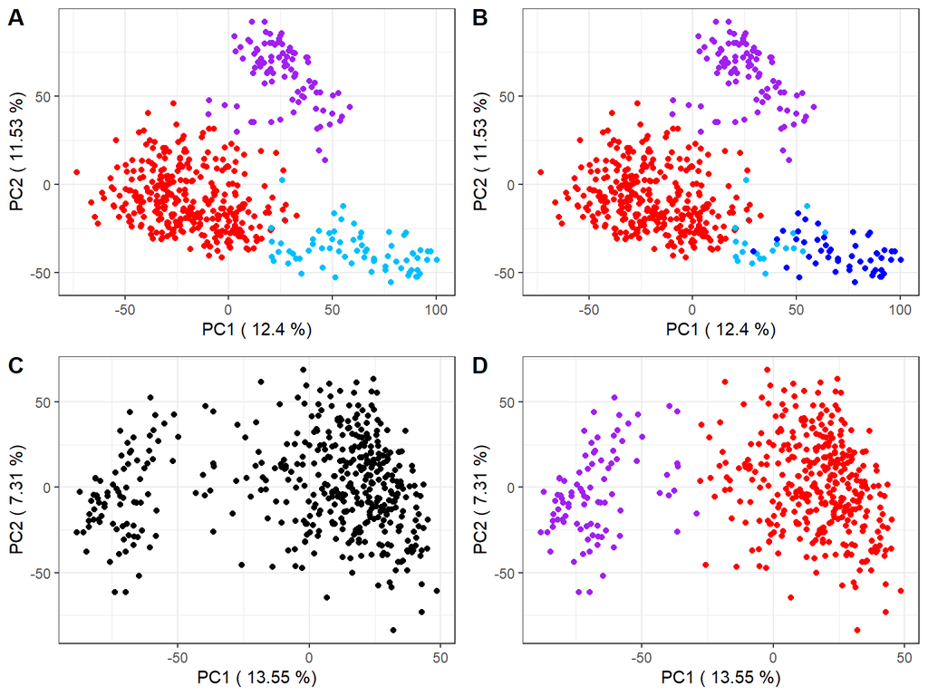

```r
#--------------------------------------------------------------------------------------
                          #PCA and k-means clustering
#--------------------------------------------------------------------------------------

#my function  for  PCA in 2 steps:
PCA <- function(data) {

pc <- prcomp(data)
pc.sum <- summary(pc)$importance
varExp <- round(pc.sum[2, ] * 100, 2)
pcs <- as.data.frame(pc$x)
fourdata <-list(pc, pc.sum, varExp, pcs)
return(fourdata)
}

PCAplot <- function(x){
  ggplot(data = x[[4]], aes(x = PC1, y = PC2 ))+geom_point()+ xlab(paste("PC1 (", x[[3]][1], "%)"))  + ylab(paste("PC2 (", x[[3]][2], "%)"))+theme_bw()+theme(legend.position = "none")
}

# PCA and k-means for all 500 samples
PCAall <-PCA(ExpMatrixLog2T)
resultsAll <- kmeans(PCAall[[4]][, 1:5], 3)
resultsAll$cluster <-as.factor(resultsAll$cluster) #essential step for later plot labeling.
kplotAll <- ggplot(data = PCAall[[4]], aes(x = PC1, y = PC2, color=resultsAll$cluster))+ xlab(paste("PC1 (", PCAall[[3]][1], "%)"))  + ylab(paste("PC2 (", PCAall[[3]][2], "%)"))+geom_point()+theme_bw()+theme(legend.position = "none") +scale_color_manual(values = c("deepskyblue1", "purple","red"))

#k-means for all 500 samples overlayed with normal samples
kplotAllHighlight <- kplot+ geom_point(data=PCAall[[4]][samplesNT,], aes(x = PC1, y = PC2), color="blue")+theme(legend.position = "none")

#PCA and k-means for only tumor samples
PCATP <- PCA(onlytumor)
PCATPplot<-PCAplot(PCATP)
resultsTP <- kmeans(PCATP[[4]][, 1:6], 2)
resultsTP$cluster<- as.factor(resultsTP$cluster)
kplotTP <-ggplot(data = PCATP[[4]], aes(x = PC1, y = PC2, color=resultsTP$cluster ))+ xlab(paste("PC1 (", PCATP[[3]][1], "%)"))  + ylab(paste("PC2 (", PCATP[[3]][2], "%)"))+geom_point()+theme_bw()+theme(legend.position = "none") +scale_color_manual(values = c("red","purple"))

#all four plots merged
fourplots <-cowplot::plot_grid(kplotAll, kplotAllHighlight, PCATPplot, kplotTP, align = "hv", nrow = 2,  labels = c('A', 'B',  "C", "D"))

print(fourplots)
```

**Figure 1. Unsupervised Clustering of Transcriptome Data. (A)** PC1/PC2 groupped the samples into three clusters. **(B)** All normal samples (in dark blue) mapped to the same cluster. **(C)** PCA and **(D)** *k*-means clustering of only tumor samples revealed two populations of breast cancer.

#### Differential Gene Expression Analysis (DEA)

Using *limma* package DEA was conducted. The analysis allowed identification of top up- and down-regulated genes depicted with the volcano plot.

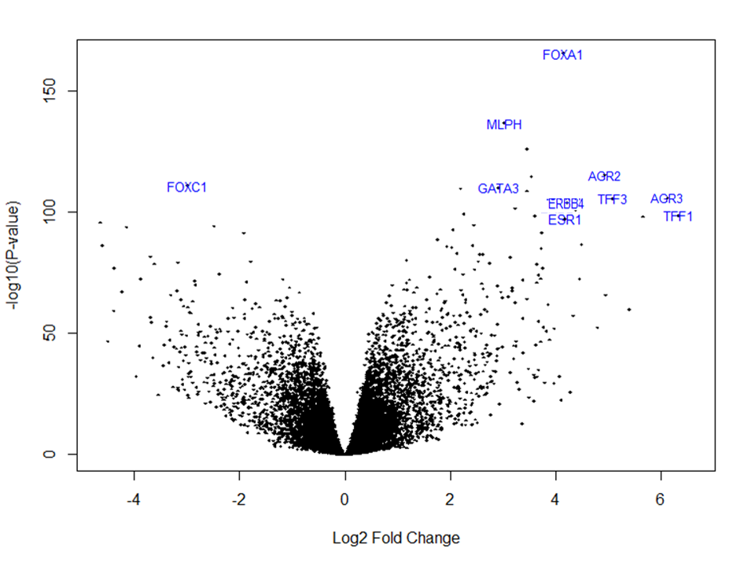

```r
#organizing data for DEA
onlytumor$cluster <- as.numeric(resultsTP$cluster) #assigning clusters to  samples
onlytumorUN <- as.data.frame(t(onlytumor)) #transposed back -this way required for limma

which(rownames(onlytumorUN)=="cluster" ) # 14900 = cluster row

#--------------------------------------------------------------------------------------
                                      #LIMMA
#--------------------------------------------------------------------------------------
groups <- as.factor(onlytumorUN[14900,]) # I provide 2 groups=clusters
designs <- model.matrix(~0 + groups, data=onlytumorUN[-14900,]) #and exclude cluster IDs from calculation


#Contrasts matrix
ContrastMat <- makeContrasts(difference = groups1-groups2, levels = designs)

fits <- lmFit(onlytumorUN[-14900,], designs)

vfits <- contrasts.fit(fits, contrasts=ContrastMat)

efits <- eBayes(vfits)

volcanoplot(efits, highlight = 20,  names = rownames(efits$coefficients), hl.col = "blue")
```

#### Pathway Enrichement Analysis (PEA)

Using Reactome database, top differentially expressed genes (DEGs) mapped to two major pathways: *ESR1* and *ERBB4*-mediated signalling cascades.

```r
#change symbol names to ENTREZ ID
top.table <- topTable(efits, number = 20) #top 20 genes from limma

toptableIDs <-clusterProfiler::bitr(rownames(top.table), 'SYMBOL', 'ENTREZID', OrgDb=org.Hs.eg.db) #ENTREZIDs should be provided

paths <- enrichPathway(gene=toptableIDs[,2], pvalueCutoff=0.05, readable=T)
pathsDF<- as.data.frame(paths)

#table output
patways <-subset(pathsDF[1:5, c("Description", "GeneRatio", "geneID")])
rownames(output) <-NULL
kbl(pathways,  caption = "Table 1. Reactome assigned top DEGs to major ESR1 and ERBB4 mediated pathways") %>%
kable_paper(full_width = F) %>%kable_styling()
```

**Table 1.** Reactome assigned top DEGs to *ESR1* and *ERBB4*-mediated pathways

| Description | GeneRatio | geneID |
| --- | --- | --- |
| Estrogen-dependent gene expression | 6/12 | FOXA1/GATA3/TFF3/ERBB4/TFF1/ESR1 |
| ESR-mediated signaling | 6/12 | FOXA1/GATA3/TFF3/ERBB4/TFF1/ESR1 |
| Signaling by Nuclear Receptors | 6/12 | FOXA1/GATA3/TFF3/ERBB4/TFF1/ESR1 |
| Nuclear signaling by ERBB4 | 2/12 | ERBB4/ESR1 |
| Signaling by ERBB4 | 2/12 | ERBB4/ESR1 |

Overall, since top DEGs mapped to *ERS1*-mediated pathways, from this point on tumor clusters will be addressed as ER-positive (ER+) and ER-negative (ER-) subgroups.

#### Methylation Data Access

Using *MultiAssayExperiment* package [26], methylation data with the matched samples from the gene expression data was obtained and aligned with the transcriptome data.

```r
#--------------------------------------------------------------------------------------
                                       #methylation data
#--------------------------------------------------------------------------------------


querymeth500 <- GDCquery(project = "TCGA-BRCA",
                 data.category = "DNA methylation",
                 platform = "Illumina Human Methylation 450",
                 legacy = TRUE,
                 barcode = samples500) #sample500 is the variable from transcriptome code

GDCdownload(querymeth500)
met500 <- GDCprepare(querymeth500, save = FALSE)
met500 <- met500[rowSums(is.na(assay(met500))) == 0,]
metsub <- subset(met500, subset = as.character(GenomicRanges::seqnames(met500)) %in% c( "chr2", "chr4", "chr6", "chr7", "chr21")) #chromosomes chosen based on some top key DEGs' chromosomal locations

#--------------------------------------------------------------------------------------
                            #MATCHING TRANSCRIPTOME AND METHYLOME DATA SETS
#--------------------------------------------------------------------------------------

rownames(exp) <- values(exp)$ensembl_gene_id  #"createMAE" should receive ENSEMBLE IDs (ENSG)
mae <- createMAE(exp = assay(geneexpr)[,samplesTP],  #so only tumor samples this time :)
                 met = metsub,
                 save = TRUE,
                 linearize.exp = TRUE,
                 save.filename = "mae.rda",
                 met.platform = "450K",
                 genome = "hg19",
                 TCGA = TRUE)

maematrlist <- MultiAssayExperiment::assays(mae)
widematrix <-  wideFormat(mae)
maematrices <- as.matrix(widematrix) #gene expression and methylation matrices together
genesprobes <- as.data.frame(maematrices)
genesprobes1<- genesprobes[,-1] # sample IDs were in the first column not as row names
rownames(genesprobes1) <- genesprobes[,1] # made them as rownames
names(genesprobes1) = gsub(pattern = "DNA.methylation_", replacement = "", x = names(genesprobes1))
#removed extra string in probe name
names(genesprobes1) = gsub(pattern = "Gene.expression_", replacement = "", x = names(genesprobes1)) #and gene name
```

#### Methylome Analysis of Breast Cancer Subtypes

Unsupervised ML was also applied to the methylome data. As opposed to the genetic subtypes revealed by transcriptome analysis, tumor samples did not fall into distinct epigenetic groups: unsupervised clustering failed to detect methylation subgroups.

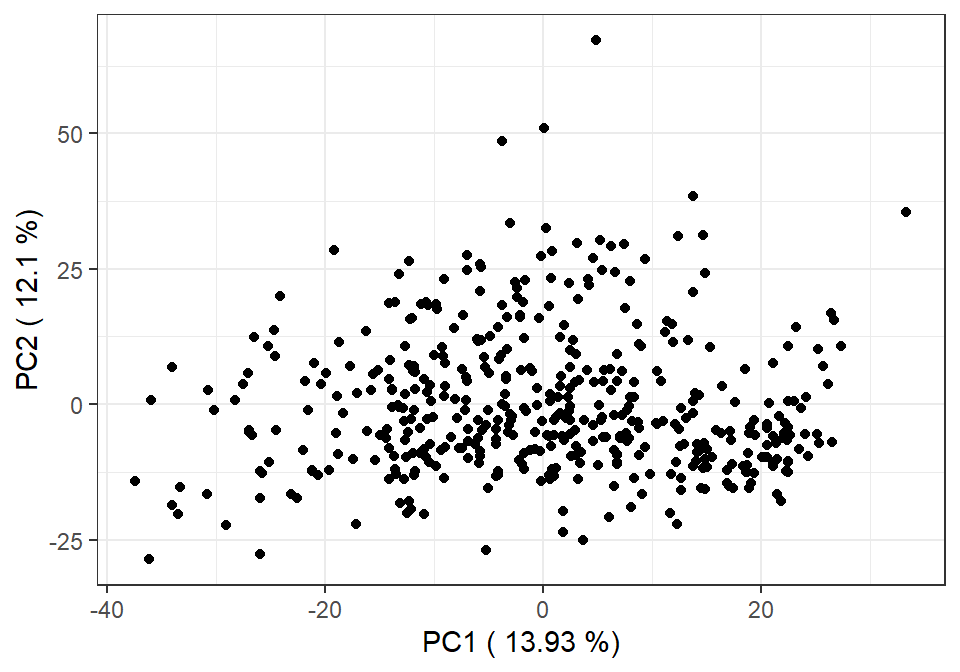

```r
#organizing methylome data for PCA
#data has already been transposed
genesprobes2 <- as.data.frame(sapply(genesprobes1, as.numeric)) #this conversion is essential for PCA.
probesonly <- genesprobes2[, -grep("ENS", colnames(genesprobes2)) # df only with probes, genes omitted. ~92K probes

#PCA of methylome
PCAprobes <- PCA(probesonly)
PCAprobesplot <- PCAplot(PCAprobes)
print(PCAprobesplot)
```

**Figure 3. Unsupervised Clustering of Methylome Data.** PCA could not detect differential methylation in breast cancer subtypes.

Next, methylation levels were tested for differentially expressed genes to find a correlation between gene expression status and methylation of CpGs associated with them. To this end, several additional operations were required to find matching probes for the genes of interest.

```r
#probe and gene annotation data
 annots = getAnnotation(IlluminaHumanMethylation450kanno.ilmn12.hg19)
 annots <- as.matrix(annots)

#genes of interest to find matching probes for
tops <- topTable(efits, number=Inf) # get all genes from DEA
DOWNS <- tops[which(tops$logFC > 0), ] [1:30,] # up-reg top 30
UPS <- tops[which(tops$logFC < 0), ] [1:30,] # down-reg top 30
UN<- tops[which(tops$P.Value > 0.09 & tops$logFC < 0.5 & tops$logFC > 0) & tops$t < 1 & tops$t > 0,] %>% drop_na()  #this is how I define non-differentially expressed genes

#first I filter data by chromosomes and then I pick gene names (string, because in annots several genes are pasted in one  column) from  upregulated gene set.  So I get a filtered annotation matrix.
ENSvecUPfinal <- dplyr::filter(annots, annots$chr==c( "chr2", "chr4", "chr6", "chr7", "chr21")) %>% dplyr::filter(grepl(paste(rownames(UPS), collapse="|"), UCSC_RefGene_Name))

#I turn it into a vector that contains only row names(=probe names) of that filtered annots matrix
vecUPS <- rownames(ENSvecUPfinal)


#The same should be performed for down-regulated and unchanged gene sets:

ENSvecDOWNfinal <- dplyr::filter(annots, annots$chr==c( "chr2", "chr4", "chr6", "chr7", "chr21")) %>% dplyr::filter(grepl(paste(rownames(DOWNS), collapse="|"), UCSC_RefGene_Name))
vecDOWNS <- rownames(ENSvecDOWNfinal)

ENSvecUNfinal <- dplyr::filter(annots, annots$chr==c( "chr2", "chr4", "chr6", "chr7", "chr21"))  %>% dplyr::filter(grepl(paste(rownames(UN[800:860, ]), collapse="|"), UCSC_RefGene_Name))
vecUN <- rownames(ENSvecUNfinal)

#Now I subset my original probes dataframe based on the variables from an external annots data.

#non-differential gene probes
MatchitUN <-intersect(colnames(probesonly), vecUN) #making sure all probes from annots can be found in my df
MatchselectUN <- select_(probesonly, .dots = MatchitUN)

#Upregulated gene probes
MatchitUP <-intersect(colnames(probesonly), vecUPS)
MatchselectUP <- select_(probesonly, .dots = MatchitUP)

#Downregulated gene probes
MatchitDOWN <- intersect(colnames(probesonly), vecDOWNS)
MatchselectDOWN  <- select_(probesonly, .dots = MatchitDOWN)

#binding all probes and  calcuating means per sample for each up-, down-regulated and unchanged gene probes.

MyProbes <- cbind(MatchselectUN, MatchselectUP, MatchselectDOWN)
MyProbes <- as.data.frame(sapply(MyProbes, as.numeric))
MyProbes$MeanProbeUN <- rowMeans(MyProbes[ , colnames(MatchselectUN)])
MyProbes$MeanProbeDOWN <- rowMeans(MyProbes[, colnames(MatchselectDOWN)])
MyProbes$MeanProbeUP <- rowMeans(MyProbes[, colnames(MatchselectUP)])


#finally correct assignment of samples to clusters was possible
MyProbes$cluster <- as.factor(onlytumor$cluster)
```

Methylation level of up- and down-regulated genes demonstrated significant variation between ER- and ER+ clusters, whereas probes corresponding to the non-differentially expressed genes showed no variance.

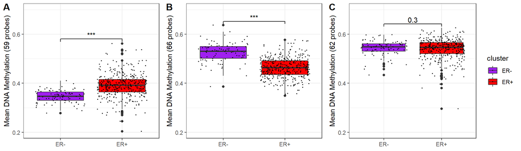

```r
#assigning clusters to ER- and ER+ groups
MyProbes$cluster <- as.character(MyProbes$cluster)
MyProbes$cluster[MyProbes$cluster == "1"] <- "ER+"
MyProbes$cluster[MyProbes$cluster == "2"] <- "ER-"


UNbox <- MyProbes[, -161] %>%ggplot(aes(x = cluster, y = MeanProbeUN, fill=cluster)) #had a probe duplication at 161 and omitted
a <-UNbox + geom_boxplot()+geom_jitter(color="black", size=0.4, alpha=0.9) + geom_signif(test ="t.test", comparisons = list(c("ER-", "ER+")), map_signif_level=FALSE)+scale_fill_manual(values=c( "purple","red" ))+ xlab(NULL) + ylab("Mean DNA Methylation (62 probes)")+theme_bw()+scale_y_continuous(limits = c(0.2, 0.7), breaks = c(0.2, 0.4, 0.6))


UPbox <- MyProbes[, -161] %>%ggplot(aes(x = cluster, y = MeanProbeUP, fill=cluster))
b<-UPbox + geom_boxplot()+geom_jitter(color="black", size=0.4, alpha=0.9)+ geom_signif(test ="t.test", comparisons = list(c("ER+", "ER-")), map_signif_level=TRUE)+scale_fill_manual(values=c("purple","red" ))+ theme(legend.position="none") +xlab(NULL) + ylab("Mean DNA Methylation (59 probes)")+theme_bw()+theme(legend.position = "none")+scale_y_continuous(limits = c(0.2, 0.7), breaks = c(0.2, 0.4, 0.6))


Downbox <- MyProbes[, -161] %>%ggplot(aes(x = cluster, y = MeanProbeDOWN, fill=cluster))
c<- Downbox + geom_boxplot()+geom_jitter(color="black", size=0.4, alpha=0.9) + geom_signif(test ="t.test", comparisons = list(c("ER+", "ER-")), map_signif_level=TRUE)+scale_fill_manual(values=c("purple","red" )) + theme(legend.position="none") +xlab(NULL) + ylab("Mean DNA Methylation (66 probes)")+theme_bw()+theme(legend.position = "none")+scale_y_continuous(limits = c(0.2, 0.7), breaks = c(0.2, 0.4, 0.6))

methboxp <-cowplot::plot_grid(b, c, a,  nrow = 1, labels = c('A', 'B', "C"), rel_widths=c(1, 1, 1.2))
print(methboxp)
```

**Figure 4. ER+ and ER- groups showed distinct methylation levels.** Groups were compared based on mean beta values of probes corresponding to the top down-regulated **(A)**, up-regulated **(B)**, and non-differentially expressed **(C)** genes.

### Discussion

TCGA database is a robust publicly available platform that has hugely contributed to better understanding of cancer and improvements in our ability to diagnose, treat and prevent the disease. Created in 2006, the platform has been hugely improved [4]. However, a few tools still remain to be fixed and better documented.

Along with the discussion of the results, I will address issues with the data acquisition and manipulation and evaluate my overall experience with *TCGA workflow* in the highlighted parts of the text.

#### Transcriptome Data Acquisition: *which data type to choose?*

Following *TCGA workflow* [9], one can acquire the “rsem.results.gene” file for each sample containing “raw_counts” and “scaled_estimates” – two data types that can be applied in the analysis.

“Scaled_estimate” represents Transcript per Million (TPM) and has lately gained more popularity as it does not require gene length normalization and tends to be more comparable between samples [10][11]. However, for an inexperienced user it could be somewhat handier to work with a bigger scale numbers such as “raw_counts”.

The first ambiguity that one encounters is that “raw_counts” are not integers as normally expected since it represents an estimation of mapping a read to a certain transcript calculated with RNA-Seq by Expectation-Maximization (RSEM) [11]. This data requires further normalization and filtering steps including log-transformation for the downstream analyses. Normalized data, in turn, can be directly acquired when requesting “rsem.genes.normalized_results” file.

Overall, such information can most of the time be inferred from certain forums and a few scientific papers[9][10][11]. Clarification of this kind of details in the *TCGA workflow* would be of great support for the users.

Additionally, one should make certain that sample type is specified while acquiring data, otherwise tumor samples will be accompanied with a few healthy controls (see more in the next section).

#### Unsupervised Clustering: *hidden data structure revealed*

Unsupervised clustering has been vastly applied in molecular cancer research and has led to important inferences such as detection of new cancer subtypes, modelling cancer risk or patient outcomes [27][28]. In simple terms, the idea of unsupervised learning is to organize unlabeled data into similarity groups called clusters [29].

PCA followed by *k*-means clustering is a common approach of unsupervised ML used to reduce dimensionality and assign observations to the clusters [12]. This powerful tool revealed main groups and allowed detection of the technical mistake made during data acquisition: normal samples mapped to the cluster detected by PC1 (Figure 1.B).

Some factors could, however, interfere with the performance of unsupervised learning algorithms. One of such limiting components can be a sample size. In fact, analyzing more samples normally lead to better defined clusters [13].

Heterogeneity in the sample population, such as different gender, age group and some other factors may also contribute to the mentioned hindrance as gene expression profiles could be largely affected. These tend to be especially important while focusing on detecting new subtypes within cancer population [13].

#### DEA and PEA: *making sense of biomarkers*

Breast cancer has been the subject to dynamic re-classification along with the new findings suggested by extensive molecular research. Currently suggested five different molecular subtypes, major distinction - hormone responsiveness - is defined by presence or absence of Estrogen or Progesterone receptor diagnosed with immunohistochemistry [5][7]. Additionally, mRNA levels can also reflect the mentioned cancer status as reported so far [7] and, to a certain extent, confirmed in this study.

Clusters showed differential expression of the gene *ESR1*, encoding Estrogen receptor alpha (ER-alpha/ER), that is in line with the literature reporting the majority of breast cancer cases being ER-positive. ER-alpha along with accompanying proteins is involved in gene expression regulation exerting physiological and malignant roles in breast tissue [14]. Ironically, overexpression of ER-alpha is considered to be one of the causes of breast cancer development by promoting uncontrollable cell growth, whereas the presence of the same protein makes patients suitable for the hormone therapy - the treatment with the best prognosis so far [14].

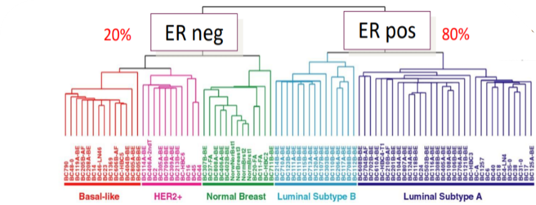

**Figure 5. Molecular Taxonomy of Breast Cancer.** Adapted from Sorlie and colleagues’ research paper [7], the diagram shows the molecular subtypes of breast cancer.

*TFF1* and *TFF3* are suggested to be valuable candidates to predict response to endocrine therapy in metastatic breast cancer. These Estrogen-regulated proteins play the role in cancer migration [16]. So are *AGR2* and *AGR3* implied in breast cancer motility. Overexpression of these secreted proteins have been associated with poor prognosis of ER+ breast cancer [17][18].

Lastly, *ERBB4* functions as an ER transcriptional co-regulator as it selectively binds to gene promoters containing estrogen response elements. Besides, *ERBB4* is itself an Estrogen-inducible gene that along with ER regulates gene expression and promotes tumor cell proliferation [20].

These biomedically sensible results were obtained using *limma* (linear models for microarray data). This pipeline uses gene-wise linear model to deduce genes contributing to ER+ and ER- populations [21].

It is somewhat more comfortable to use the original *limma* package compared to the *TCGAbiolinks* in-built function. The latter one is also based on *limma* or *edgeR* packages but strictly requires separate data matrices and a few extra parameters which would require additional unnecessary effort for unsupervised learning.

As for Pathway Enrichment Analysis (PEA), Reactome database managed to generate sensible results [22]. It has the specific aim to annotate genes to molecular pathways and is now slowly replacing its predecessor KEGG – also embedded in *TCGAbiolinks* that did not succeed in mapping genes to the most relevant pathways [4].

A suggested improvement to Reactome would be to output hierarchical relations between pathways also in R environment similar to the website [22], instead of misleadingly listing them as independent pathways (Table 1).

#### Methylome Analysis: *challenges in data matching and interpretation*

Epigenetic modifications have been of special interest in cancer research. Global hypomethylation and tumor-suppressor gene-specific hypermethylation of cancerous cells compared to the normal tissues represents one of the established paradigms that further research builds upon [23].

Regardless of its raising importance, however, methylome analysis still remains a challenging processes. Microarrays testing methylation of CpG sites seem to fail to provide accurate data due to high technical noise. A few normalization steps suggested so far have been argued to influence different outcomes; thus, the universally best way has not been established [24][30].

A simple analysis conducted in this study did not focus on specific CpG sites but rather on detecting correlation between differentially expressed genes and the mean methylation of their corresponding probes. The analysis revealed that top up- and down-regulated genes in ER+ population are hypo- and hyper-methylated, respectively. These results are in line with our current understanding of gene expression regulation mechanisms: methylation of gene promoter leads to gene silencing, whereas regulatory regions of actively transcribed genes tend to be demethylated, enabling transcription machinery to access gene-coding segments of DNA [25].

Interestingly, testing methylation of the whole biomarker genome region instead of the whole genome has been suggested for cancer diagnostic purposes, thus avoiding the noise associated with the microarray-derived data [31].

Concerning unsupervised clustering of the methylome data, the fact that it failed to generate clusters was expected due to the nature of the data one has to deal with. Firstly, all samples were cancerous, thus global methylation differences between two subtypes of breast cancer would not be as obvious as those between cancerous and normal tissues; Secondly, proportion of differentially methylated probes may not be high enough to influence the clustering as opposed to the DEGs (100K probes vs 14K genes). Moreover, not all probes were addressed in PCA since the data from only five pre-selected chromosomes were obtained. Lastly, it is not evident how the data was normalized.

Handling methylome data was of particular difficulty. Matching methylation and gene expression data was made possible by *MultiAssayExperiment* package [26]. However, due to the volume of methylome data, pre-selection of chromosomes is an essential step while working on 16 RAM windows system. Therefore, before the analysis, locations of genes of interest should be considered and only CpG loci located on those chromosomes extracted.

Matching the probes to the nearest genes, however, is another step not provided by the *TCGA workflow*. In fact, the suggested *ELMER* pipline only focuses on cis-regulatory networks and does not consider a simple mapping of all probes to their genes [9]. To this end, an external annotation matrix can be acquired using *IlluminaHumanMethylation450kanno.ilmn12.hg19* package. The same information can also be found in the file supplemented during methylome data acquisition. However, due to its size, it cannot be loaded into the R environment.

Finally, it is not straightforward to find out which normalization method has been applied to the methylome data. *TCGA workflow* does not suggest any downstream normalization steps either. Thus, the data could have been more informative if these details had been known.

### Conclusion

Unsupervised clustering detected two major molecular subtypes of breast cancer - ER-positive and ER-negative. Responsiveness to Estrogen molecules, mediated by overexpression of receptor known as ER-alpha, is of biological and clinical importance. Besides, genes involved in ER-mediated pathway also differ significantly between the ER clusters and have been considered for the clinical implementation [15-20]. Thus, inferences from this project study is in line with the recent findings of molecular biology of breast cancer.

Genetic subtypes revealed by unsupervised learning did not show epigenetic differences when evaluating methylation with PCA. For more confident interpretation, a methylome dataset requires a closer look and testing several normalization steps [24][30]. When narrowing down to certain genes, however, methylome data managed to generate reasonable results: hypo- and hyper-methylation of up- and down-regulated genes, respectively, were observed.

In summary, TCGA database still requires further improvements in terms of documentation, incorporation of additional functions and fixing the existing ones for more flexibility in data processing.

I would like to briefly summarize my impressions concerning the peculiarities I observed while working on my first project in bioinformatics: trial and error rounds have comprised the majority of project time; re-approaching the results, digging into the errors, mastering searching skills and making sense of the data tend to be the major tasks one has to deal with. Timely support from a supervisor plays an immense role in these processes.  
Gained confidence while dealing with huge datasets, better understanding of statistical concepts, improved programming language skills and finally, a reward after being able to generate sensible results, were worth the challenges the project has implied. I believe, it is a strongly recommended experience for all wet-lab scientists to start filling the gaps that IT has introduced into biomedical research.

### References

1. Yeatman, T. (2003). “The future of cancer management: translating the genome, transcriptome, and proteome.” 10(1): 7-14.
2. Shyr, D. and Q. J. Liu (2013). “Next generation sequencing in cancer research and clinical application.” 15(1): 4.
3. Morozova, O., et al. (2009). “Applications of new sequencing technologies for transcriptome analysis.” 10: 135-151.
4. National Cancer Institute. 2020. The Cancer Genome Atlas Program. [online]  
   https://www.cancer.gov/about-nci/organization/ccg/research/structural-genomics/tcga [Accessed 30 September 2020].
5. Nascimento, R. G. and K. M. Otoni (2020). “Histological and molecular classification of breast cancer: what do we know?”.
6. Viale, G. (2012). “The current state of breast cancer classification.” 23(suppl_10): x207-x210.
7. Sørlie, T., et al. (2001). “Gene expression patterns of breast carcinomas distinguish tumor subclasses with clinical implications.” 98(19): 10869-10874.
8. Ma, X., et al. (2013). “DNA methylation data analysis and its application to cancer research.” 5(3): 301-316
9. Bioconductor.org. 2020. TCGA Workflow: Analyze Cancer Genomics And Epigenomics Data Using Bioconductor Packages. [online]  
   https://www.bioconductor.org/packages/release/workflows/vignettes/TCGAWorkflow/inst/doc/TCGAWorkflow.html [Accessed 29 October 2020].
10. Seqanswers.com. 2020. Whicn Normalization Methods Are Used For Rnaseqv2 Data At TCGA? [online] http://seqanswers.com/forums/showthread.php?t=42911  
    [Accessed 29 October 2020].
11. Li, B. and Dewey, C (2011). “RSEM: accurate transcript quantification from RNA-Seq data with or without a reference genome.” 12(1): 323.
12. Ding, C. and He, X. (2004). K-means clustering via principal component analysis. Proceedings of the twenty-first international conference on Machine learning
13. Vidman, L., et al. (2019). “Cluster analysis on high dimensional RNA-seq data with applications to cancer research-An evaluation study.” 14(12): e0219102.
14. Korach, K. S., et al. (2019). Physiological and Pathological Roles of Estrogen Receptor. Estrogen Receptor and Breast Cancer, Springer: 15-47.
15. Yoon, N. K., et al. (2010). “Higher levels of GATA3 predict better survival in women with breast cancer.” 41(12): 1794-1801.
16. Prest, S. J., et al. (2002). “The estrogen‐regulated protein, TFF1, stimulates migration of human breast cancer cells.” 16(6): 592-594.
17. Salmans, M. L., et al. (2013). “The estrogen-regulated anterior gradient 2 (AGR2) protein in breast cancer: a potential drug target and biomarker.” 15(2): 1-14.
18. Obacz, J., et al. (2019). “Extracellular AGR3 regulates breast cancer cells migration via Src signaling.” 18(5): 4449-4456.
19. Wang, J., et al. (2017). “FOXC 1 is associated with estrogen receptor alpha and affects sensitivity of tamoxifen treatment in breast cancer.” 6(1): 275-287
20. Zhu, Y., et al. (2006). “Coregulation of estrogen receptor by ERBB4/HER4 establishes a growth-promoting autocrine signal in breast tumor cells.” 66(16): 7991-7998.
21. Ritchie, M. E., et al. (2015). “limma powers differential expression analyses for RNA-sequencing and microarray studies.” 43(7): e47-e47.
22. Reactome.org. 2020. Home - Reactome Pathway Database. [online] : https://reactome.org/ [Accessed 29 November 2020].
23. Ehrlich, M. (2009). “DNA hypomethylation in cancer cells.” 1(2): 239-259.
24. Wilhelm-Benartzi, C. S., et al. (2013). “Review of processing and analysis methods for DNA methylation array data.” 109(6): 1394-1402.
25. Gibney, E. and Nolan, C. (2010). “Epigenetics and gene expression.” 105(1): 4-13.
26. MultiAssay Special Interest Group., 2020. Multiassayexperiment: The Integrative Bioconductor Container. [online] Bioconductor.org.  
    https://www.bioconductor.org/packages/release/bioc/vignettes/MultiAssayExperiment/inst/doc/MultiAssayExperiment.html [Accessed 5 November 2020].
27. Gao, S., et al. (2017). “Unsupervised clustering reveals new prostate cancer subtypes.” 6(3): 561-572.
28. Kourou, K., et al. (2015). “Machine learning applications in cancer prognosis and prediction.” 13: 8-17.
29. Hinton, G. E., et al. (1999). “Unsupervised learning: foundations of neural computation, MIT press.”
30. Bioconductor.org. 2020. A Cross-Package Bioconductor Workflow For Analysing Methylation Array Data. [online] Available at:  
    https://bioconductor.org/packages/devel/workflows/vignettes/methylationArrayAnalysis/inst/doc/methylationArrayAnalysis.html  
    [Accessed 5 November 2020].
31. Sanchez, R., et al. (2019). “Discrimination of DNA methylation signal from background variation for clinical diagnostics.” 20(21): 5343.